# Overview of the ‘pals’ package

## pal.sineramp()

The test image shows a sine wave superimposed on a ramp of the palette. The amplitude of the sine wave is dampened/modulated from full at the top of the image to 0 at the bottom.

### What to look for:

1. Along the top edge, is the sine wave equally visible across the entire image?
2. Along the bottom edge, is the ramp smooth, or are there vertical bands?

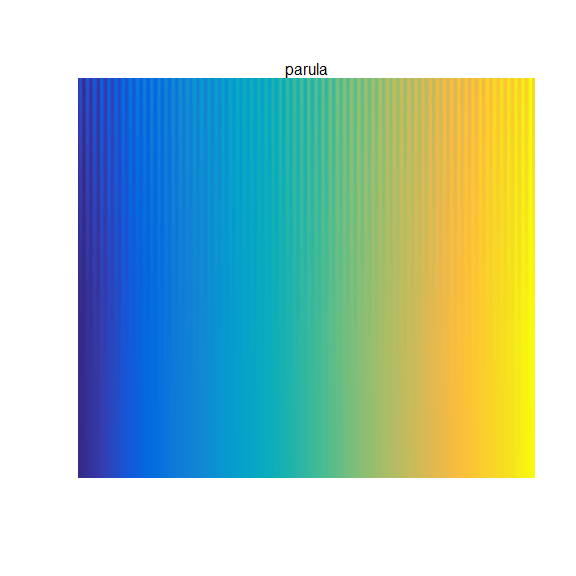

```r
pal.sineramp(parula, main="parula")
```

In the example below, the `jet` colormap fails both tests, the `tol.rainbow` colormap fails to clearly show the sinewave in the green/orange region.

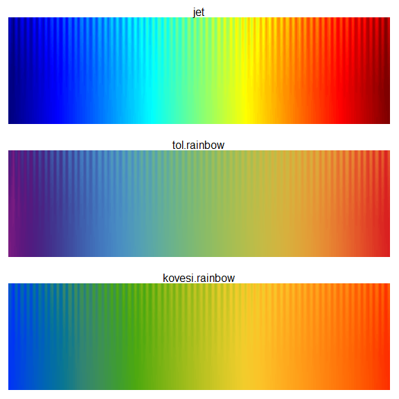

```r
op <- par(mfrow=c(3,1), mar=c(1,1,2,1))
pal.sineramp(jet, main="jet")
pal.sineramp(tol.rainbow, main="tol.rainbow")
pal.sineramp(kovesi.rainbow, main="kovesi.rainbow")
```

```r
par(op)
```

## pal.test()

This function combines several other functions into a single test image.

### What to look for:

1. Are all squares (especially upper left and lower right) in the Z-curve distinct?
2. Are the contrast sensitivity function bands visible?
3. Is the sinewave showing bands of similar height, and smoothly varying along the bottom?
4. Is the actual peak of the volcano identifiable? The lowest area?
5. Is the gray/luminosity channel monotonic?

The examples below show the poor performance of the ‘viridis’ colormap in dark regions.

The ‘parula’ palette shows more structure in the peak of the volcano.

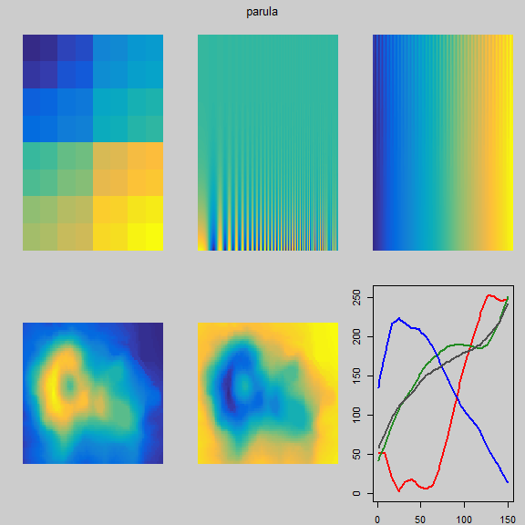

```r
pal.test(parula)
```

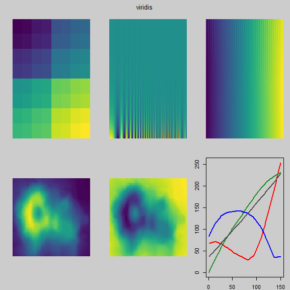

```r
pal.test(viridis) # dark colors are poor
```

## pal.volcano()

Some palettes with dark colors at one end of the palette hide the shape of the volcano in the dark colors.

### What to look for:

1. Can you locate the exact position of the highest point on the volcano?
2. Are the upper-right and lower-right corners the same elevation?
3. Do any Mach bands circle the peak?

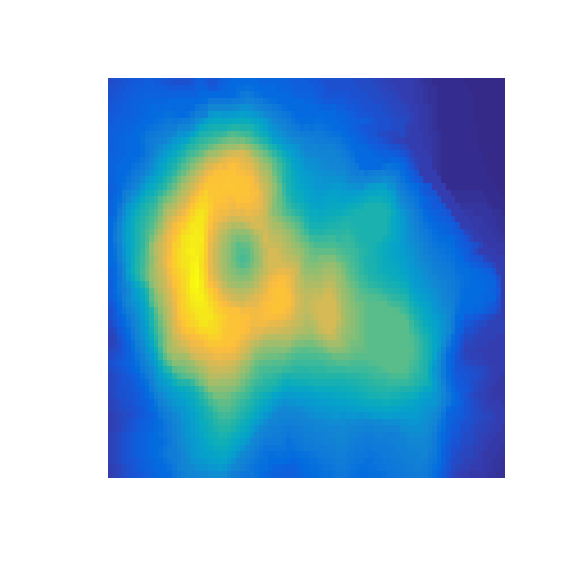

```r
pal.volcano(parula)
```

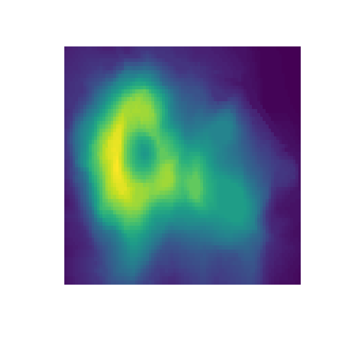

```r
pal.volcano(viridis)
```

## pal.zcurve()

### What to look for:

1. A good color palette of 64 colors should be able to resolve 4 sub-squares within each of the 16 squares.

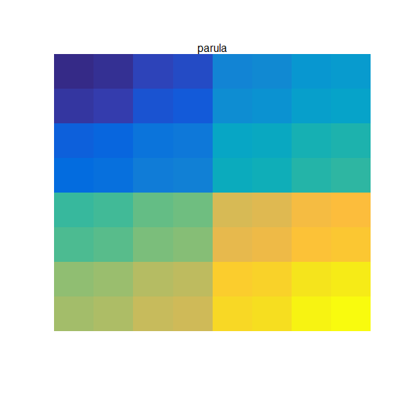

```r
pal.zcurve(parula, main="parula")
```

# Using palettes with ggplot2

To use any colormap with the `ggplot2` package, use the `ggplot2::scale_fill_gradientn()` function.

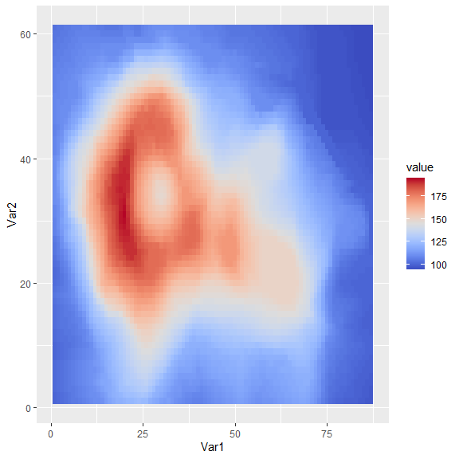

```r
require(ggplot2)
require(pals)
require(reshape2)
ggplot(melt(volcano), aes(x=Var1, y=Var2, fill=value)) +
  geom_tile() +
  scale_fill_gradientn(colours=coolwarm(100), guide = "colourbar")
```

# Catalog of colormaps and palettes

```r
# Discrete
pal.bands(alphabet, alphabet2, cols25, glasbey, kelly, okabe, polychrome, stepped, stepped2, stepped3, tol, watlington,
          main="Discrete", show.names=FALSE)
```

```
## Only 26 colors are available with 'alphabet'
```

```
## Only 26 colors are available with 'alphabet2'
```

```
## Only 25 colors are available with 'cols25'.
```

```
## Only 32 colors are available with 'glasbey'.
```

```
## Only 22 colors are available with 'kelly'.
```

```
## Only 8 colors are available with 'okabe'.
```

```
## Only 36 colors are available with 'polychrome'.
```

```
## Only 24 colors are available with 'stepped'
```

```
## Only 20 colors are available with 'stepped2'.
```

```
## Only 20 colors are available with 'stepped3'.
```

```
## Only 12 colors are available with 'tol'
```

```
## Only 16 colors are available with 'watlington'.
```

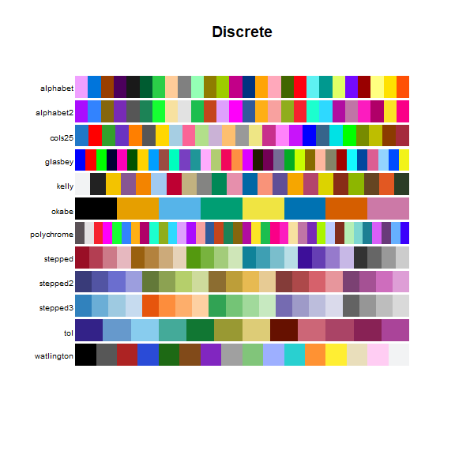

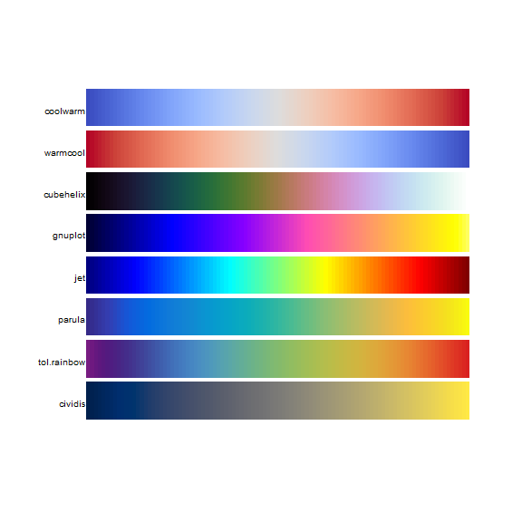

```r
# Misc
pal.bands(coolwarm,warmcool,cubehelix,gnuplot,jet,parula,tol.rainbow,cividis)
```

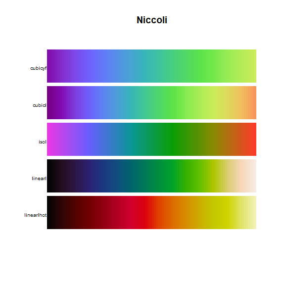

```r
# Niccoli
pal.bands(cubicyf,cubicl,isol,linearl,linearlhot,
          main="Niccoli")
```

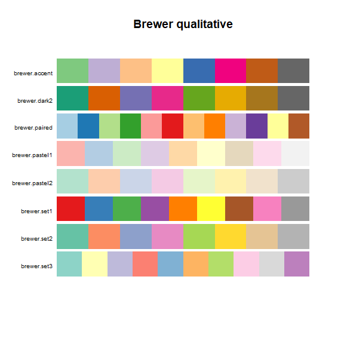

```r
# Qualtitative
pal.bands(brewer.accent(8), brewer.dark2(8), brewer.paired(12), brewer.pastel1(9),
          brewer.pastel2(8), brewer.set1(9), brewer.set2(8), brewer.set3(10),
          labels=c("brewer.accent", "brewer.dark2", "brewer.paired", "brewer.pastel1",
                   "brewer.pastel2", "brewer.set1", "brewer.set2", "brewer.set3"),
          main="Brewer qualitative")
```

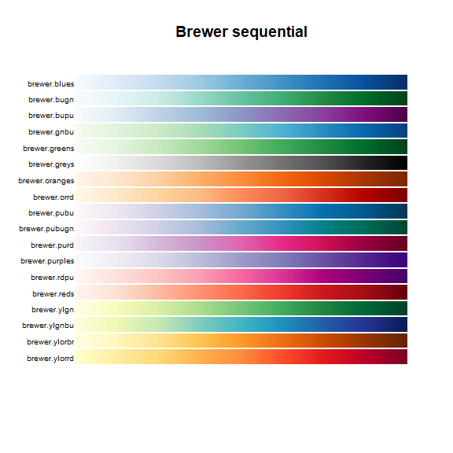

```r
# Sequential
pal.bands(brewer.blues, brewer.bugn, brewer.bupu, brewer.gnbu, brewer.greens,
          brewer.greys, brewer.oranges, brewer.orrd, brewer.pubu, brewer.pubugn,
          brewer.purd, brewer.purples, brewer.rdpu, brewer.reds, brewer.ylgn,
          brewer.ylgnbu, brewer.ylorbr, brewer.ylorrd,
          main="Brewer sequential")
```

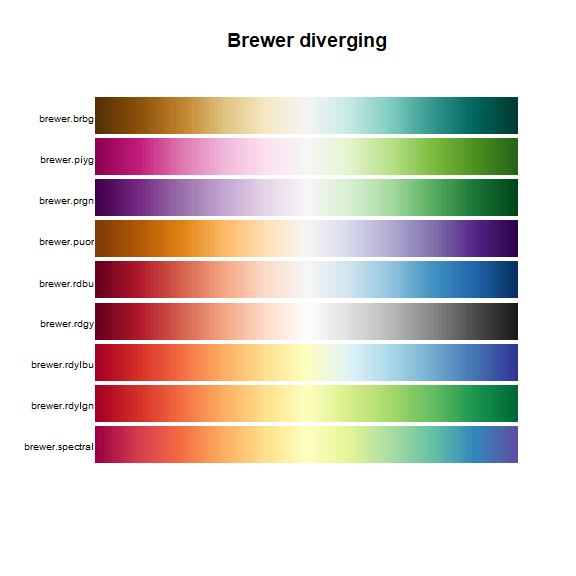

```r
# Diverging
pal.bands(brewer.brbg, brewer.piyg, brewer.prgn, brewer.puor, brewer.rdbu,
          brewer.rdgy, brewer.rdylbu, brewer.rdylgn, brewer.spectral,
          main="Brewer diverging")
```